# Moments and Descriptive Statistics

POLS 602  
Fall 2026

Mike Burnham

Texas A&M University

## Announcements

# Dot Products and Norms

## Dot Product

*The sum of the product of corresponding numbers in two vectors.*

For vectors $\mathbf{a} = (a_1, a_2, \dots, a_n)$ and $\mathbf{b} = (b_1, b_2, \dots, b_n)$:

From components:
$$\mathbf{a} \cdot \mathbf{b} = \sum_{i=1}^n a_i b_i$$

From angle:
$$\mathbf{a} \cdot \mathbf{b} = \lVert \mathbf{a} \rVert \, \lVert \mathbf{b} \rVert \cos\theta$$

where $\theta$ is the angle between $\mathbf{a}$ and $\mathbf{b}$.

## Dot Product

- The dot product always returns a scalar
- Vectors must have the same number of elements to calculate
- The dot product tells you the degree to which two vectors point in the same direction

## Norm

*A function that assigns a strictly positive size value to a vector*

L1 norm (Taxicab/Manhattan Norm): The sum of the absolute values of a vector’s components.
$$\lVert \mathbf{a} \rVert_1 = \sum_{i=1}^n |a_i|$$

L2 norm (Euclidean Norm): The straight line distance.
$$\lVert \mathbf{a} \rVert_2 = \sqrt{\sum_{i=1}^n a_i^2}$$

# Moments

## Moments

A **Moment** is *a specific quantitative measure related to the shape of a function or the properties of a distribution*

- In statistics, the function we are describing is generally a probability density function (PDF) or a probability mass function (PMF)

## PDF vs. PMF

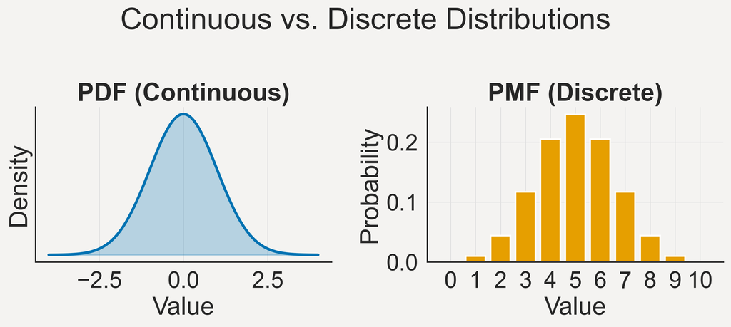

## Moments

A **Moment** is *a specific quantitative measure related to the shape of a function or the properties of a distribution*

- In statistics, the function we are describing is generally a probability density function (PDF) or a probability mass function (PMF)
- The *n*-th moment of a variable *X* around a value of *c* is defined as $E[(X-c)^n]$.
- If $c = \mu$ that is the *central moment*

# Central Tendency

## Mean

*The first moment. The sum of values divided by the number of values.*

$$\mu = \frac{1}{n} \sum_{i=1}^n x_i = \frac{1}{n} \mathbf{1}^\top \mathbf{x}$$

where $\mathbf{x} = (x_1, \dots, x_n)$ and $\mathbf{1}$ is the length-$n$ vector of ones.

Sample mean:

$$\bar{x} = \frac{1}{n} \sum_{i=1}^n x_i = \frac{1}{n} \mathbf{1}^\top \mathbf{x}$$

## Mean

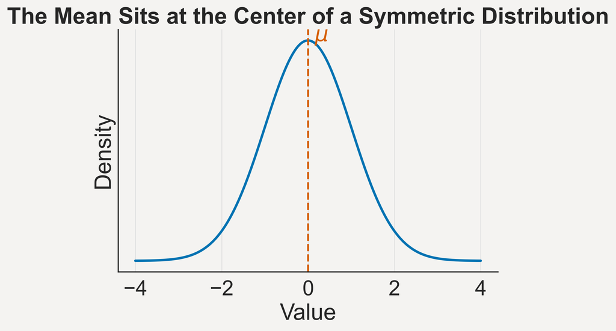

## Mean

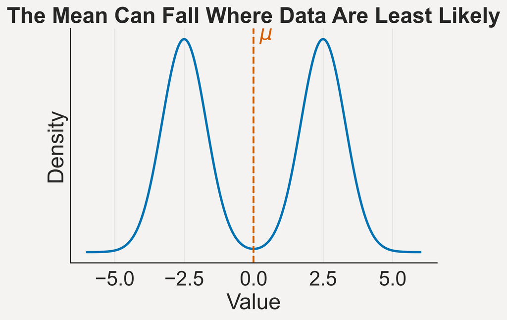

## Notation

- $\mu$ — population mean (a Greek letter denotes a population *parameter*)
- $\bar{x}$ — sample mean (a Roman letter, often barred or hatted, denotes a *statistic* estimated from data)
- $\hat{\mu}$ - estimation of the population mean
- $E[Y]$ — expected value operator (used in probability theory for the theoretical mean of a random variable $Y$, regardless of population or sample)
- $E[Y \mid X]$ — conditional expected value operator (the expected value of $Y$ given a specific value of $X$)

## Median

*The middle value of a sorted set of numbers.*

$$\text{median}(\mathbf{x}) =
\begin{cases}
x_{\left(\frac{n+1}{2}\right)} & n \text{ odd} \\[4pt]
\dfrac{1}{2}\left(x_{\left(\frac{n}{2}\right)} + x_{\left(\frac{n}{2}+1\right)}\right) & n \text{ even}
\end{cases}$$

where $x_{(i)}$ denotes the $i$-th smallest value of $\mathbf{x}$.

## Median

The median is a **Robust** statistic.

Robust statistics are *statistics that maintain their properties even when assumptions about the underlying distribution are violated.*

## Mean vs. Median

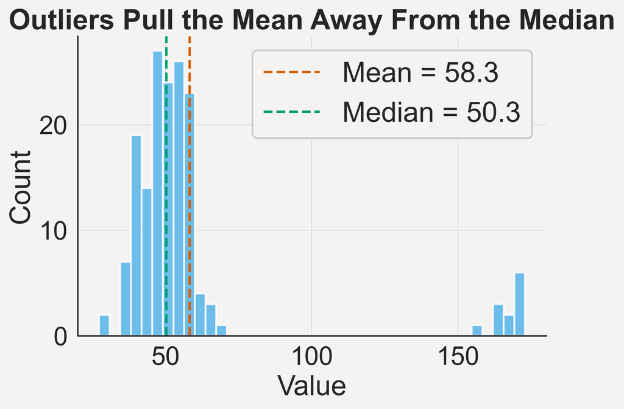

# Spread

## Variance

*The second moment. The average squared deviation from the mean.*

$$\sigma^2 = \frac{1}{n} \sum_{i=1}^n (x_i - \mu)^2 = \frac{1}{n} (\mathbf{x} - \mu\mathbf{1})^\top (\mathbf{x} - \mu\mathbf{1})$$

Sample variance:

$$s^2 = \frac{1}{n-1} \sum_{i=1}^n (x_i - \bar{x})^2 = \frac{1}{n-1} (\mathbf{x} - \bar{x}\mathbf{1})^\top (\mathbf{x} - \bar{x}\mathbf{1})$$

## Standard Deviation

*The square root of the variance, in the same units as $\mathbf{x}$.*

$$\sigma = \sqrt{\sigma^2} = \frac{1}{\sqrt{n}} \lVert \mathbf{x} - \mu\mathbf{1} \rVert_2$$

Sample version:

$$s = \sqrt{s^2} = \frac{1}{\sqrt{n-1}} \lVert \mathbf{x} - \bar{x}\mathbf{1} \rVert_2$$

## Standard Deviation

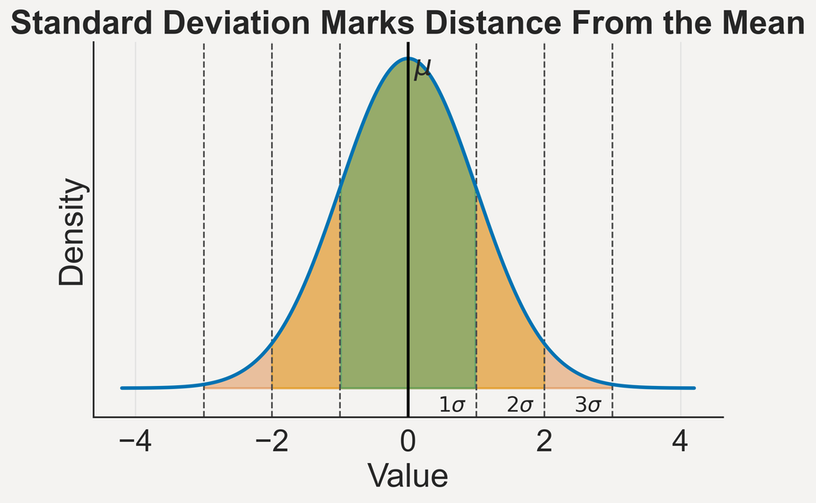

## Z-Score

*The number of standard deviations a value is from the mean.*

$$z_i = \frac{x_i - \mu}{\sigma}$$

In vector form:

$$\mathbf{z} = \frac{\mathbf{x} - \mu\mathbf{1}}{\sigma}$$

## Notation

- $\sigma^2$ — population variance
- $s^2$ — sample variance
- $\sigma$, $s$ — population and sample standard deviation, respectively
- $\text{Var}(X)$ — the variance operator, used in probability theory for the theoretical variance of a random variable $X$

# Skewness

## Skewness

*The third moment. The asymmetry of a distribution around its mean.*

$$\gamma_1 = \frac{\dfrac{1}{n}\sum_{i=1}^n (x_i - \mu)^3}{\sigma^3}$$

Sample version:

$$g_1 = \frac{\dfrac{1}{n}\sum_{i=1}^n (x_i - \bar{x})^3}{s^3}$$

## Skewness

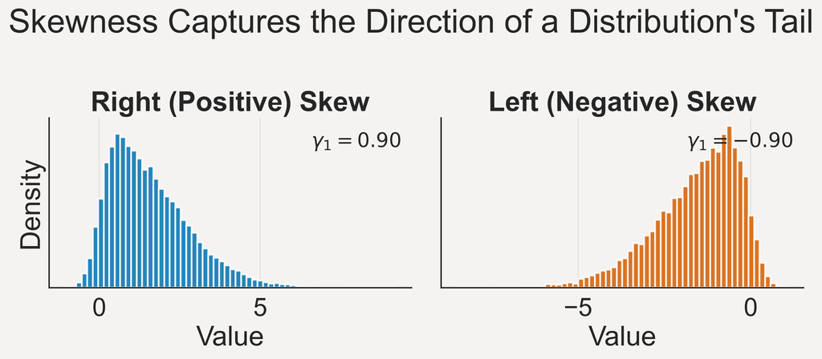

## Notation

- $\gamma_1$ — population skewness
- $g_1$ — sample skewness

# Covariance and Correlation

## Covariance

*A measure of how two random variables change together.*

$$\sigma_{XY} = \frac{1}{n}\sum_{i=1}^n (x_i - \mu_X)(y_i - \mu_Y)$$

**Covariance is a dot product**

Let $\tilde{\mathbf{x}} = \mathbf{x} - \mu_X\mathbf{1}$ and $\tilde{\mathbf{y}} = \mathbf{y} - \mu_Y\mathbf{1}$:

$$\sigma_{XY} = \frac{1}{n} \, \tilde{\mathbf{x}} \cdot \tilde{\mathbf{y}}$$

## Pearson Correlation

*Covariance rescaled to fall between -1 and 1.*

$$\rho_{XY} = \frac{\sum_{i=1}^n (x_i - \mu_X)(y_i - \mu_Y)}{\sqrt{\sum_{i=1}^n (x_i-\mu_X)^2}\sqrt{\sum_{i=1}^n (y_i-\mu_Y)^2}}$$

As a dot product:

Let $\tilde{\mathbf{x}} = \mathbf{x} - \mu_X\mathbf{1}$ and $\tilde{\mathbf{y}} = \mathbf{y} - \mu_Y\mathbf{1}$:

$$\rho_{XY} = \frac{\tilde{\mathbf{x}} \cdot \tilde{\mathbf{y}}}{\lVert \tilde{\mathbf{x}} \rVert_2 \, \lVert \tilde{\mathbf{y}} \rVert_2}$$

## Pearson Correlation

The correlation coefficient can also be expressed in terms of z-scores.

Let $\mathbf{z}_X = \dfrac{\tilde{\mathbf{x}}}{\sigma_X}$ and $\mathbf{z}_Y = \dfrac{\tilde{\mathbf{y}}}{\sigma_Y}$:

$$\rho_{XY} = \frac{1}{n} \, \mathbf{z}_X \cdot \mathbf{z}_Y$$

## Correlation

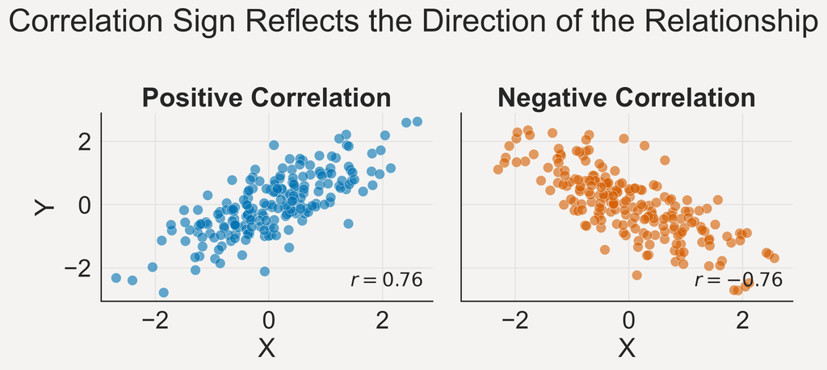

## Correlation

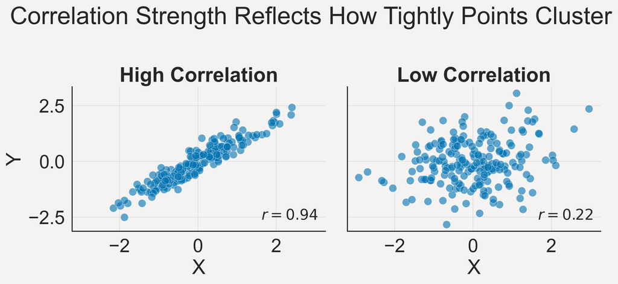

## Notation

- $\sigma_{XY}$ — population covariance between $X$ and $Y$
- $\text{Cov}(X,Y)$ - covariance operator
- $s_{XY}$ — sample covariance
- $\rho_{XY}$ — population correlation coefficient
- $r_{XY}$ (often just $r$) — sample correlation coefficient (Pearson’s $r$)